# The Research Process

## Biological research generally divides into two camps

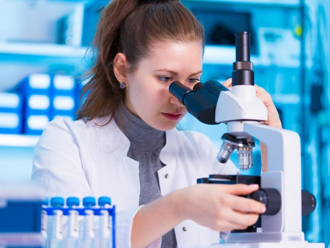

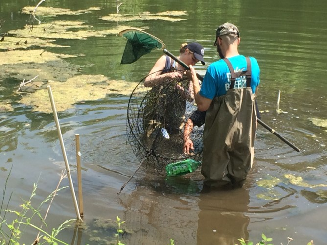

**Cell / molecular / biomedical**

**Ecology / organismal**

## Biological research generally divides into two camps

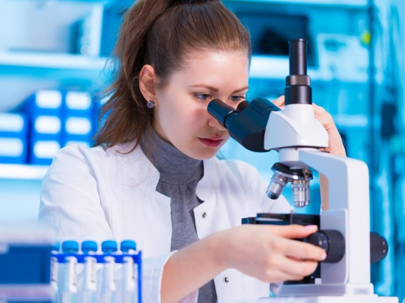

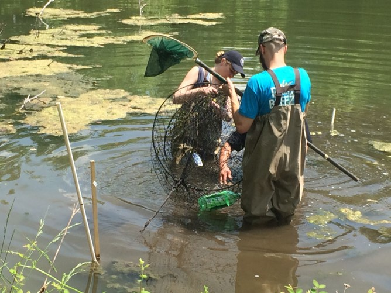

**Cell / molecular / biomedical**

**Ecology / organismal**

**BUT… the basic principles underlying both are exactly the same!**

**There is more crossover in these disciplines than ever before**

## What is the point of doing research?

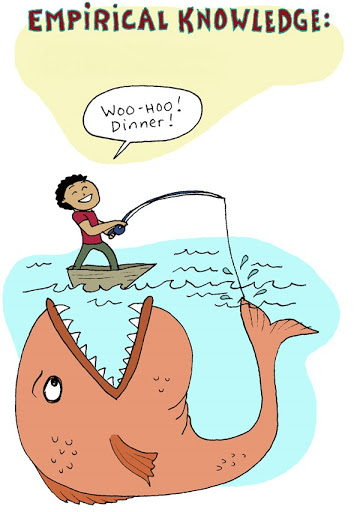

## Two types of reasoning used in science

**Two kinds of reasoning (or logic) are used in scientific research:**

1. *Inductive reasoning*: takes a specific example and induces that it can be applied to a much larger group
2. *Deductive reasoning*: starts with a general principle & deduces that it applies to a specific case

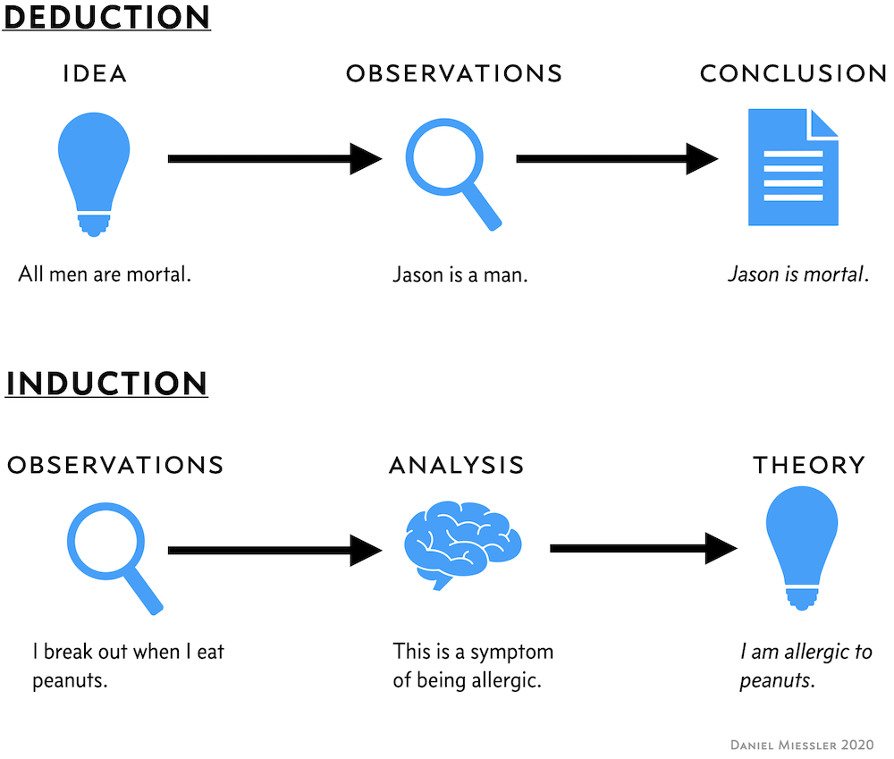

**Generally…**

- **Inductive reasoning is used in an attempt to discover a new piece of information**
- **Deductive reasoning is used to prove that piece of information**

[figure not shown]

## Inferences applied to Evolution by Natural Selection

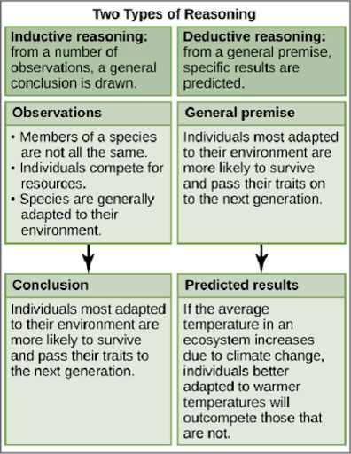

[figure not shown]

## Lets practive: Which type of reasoning?

**Every day, I get in my car to leave for work, at 8:00am. The trip takes 45 minutes, and I arrive at work on time. If I leave for work at 8:00am today, I will be on time.**

**Today, I left for work at eight o’clock and was on time. Therefore, every day that I leave the house at eight o’clock, I will arrive at work on time.**

[figure not shown]

## Lets practice: Which type of reasoning?

**Every day, I get in my car to leave for work, at 8:00am. The trip takes 45 minutes, and I arrive at work on time. If I leave for work at 8:00am today, I will be on time.**

**Today, I left for work at eight o’clock and was on time. Therefore, every day that I leave the house at eight o’clock, I will arrive at work on time.**

**All dogs are mammals, and all mammals have kidneys. Therefore, dogs must have kidneys.**

**Hamsters, cats, humans, and platypuses have kidneys. All of these animals are mammals. Therefore, all mammals have kidneys.**

[figure not shown]

## The importance of model organisms

**In many areas of biology, model organisms are used to gather information that can be applied more generally to other organisms**

**Society has decided it is ethical to perform experiments on animals that benefit human society**

**Ultimate example of *inductive reasoning*, but there are pitfalls**

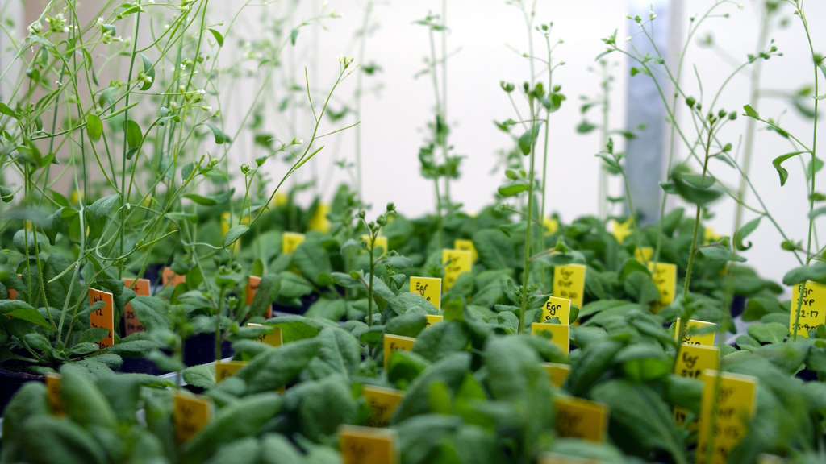

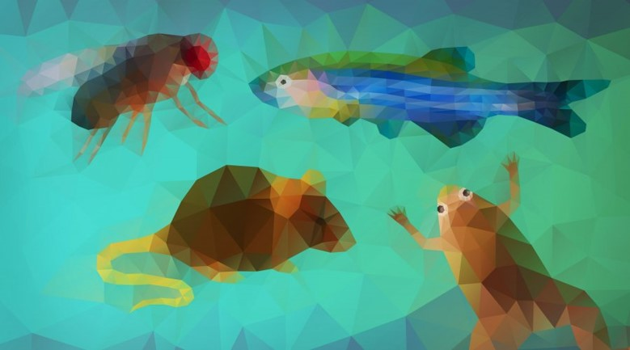

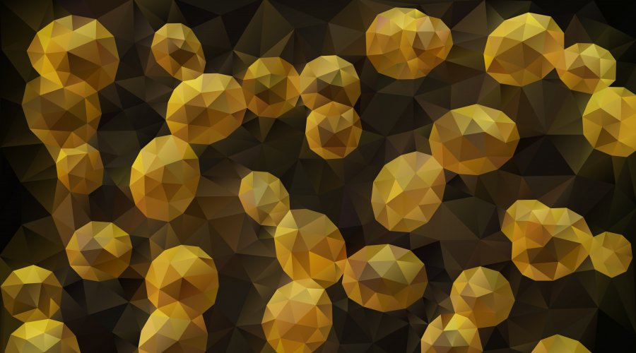

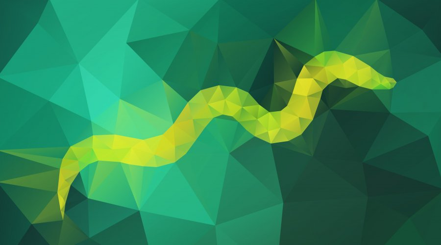

## The scientific process is the method scientists use to study things

**Based on observation and analysis of data:**

1. Make observations
2. Develop a question and form a logical hypothesis
- **A hypothesis is a tentative answer to a well-framed scientific question**
1. Test predictions arising from the hypothesis (with experiment or more observation)
2. Analyze experimental data
3. Revise hypothesis and repeat

**The scientific process is ongoing.**

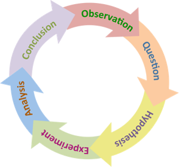

## A hypothesis is an explanation for an observation

- **A hypothesis is a tentative explanation—it isn’t written in stone**
- **Occam’s razor is the principle that the simplest explanation (i.e. having the fewest assumptions/steps) is usually correct**
- **A hypothesis must be both testable and falsifiable**
  - a hypothesis that a ghost cast a spell on a car to make it stop working cannot be tested
- **Hypotheses should strive to distinguish between causality and correlation**
  - Two things that are correlated are not necessarily causally linked
- **Other factors to consider regarding causality:**
  - are there multiple causal factors?
  - Is there a direct or indirect (remote) cause?

## An experiment is a test of a hypothesis

- **Predictions (if this, then that…) arise out of hypotheses that can be tested by experiments**
  - Good experimental design strives to disprove a hypothesis
- **Scientists often perform controlled experiments in which an experimental group is compared with a control group**
- **Ideally, experimental and control groups differ in only the one factor under investigation**
  - Controls are necessary to rule out the effects of other factors that might affect results

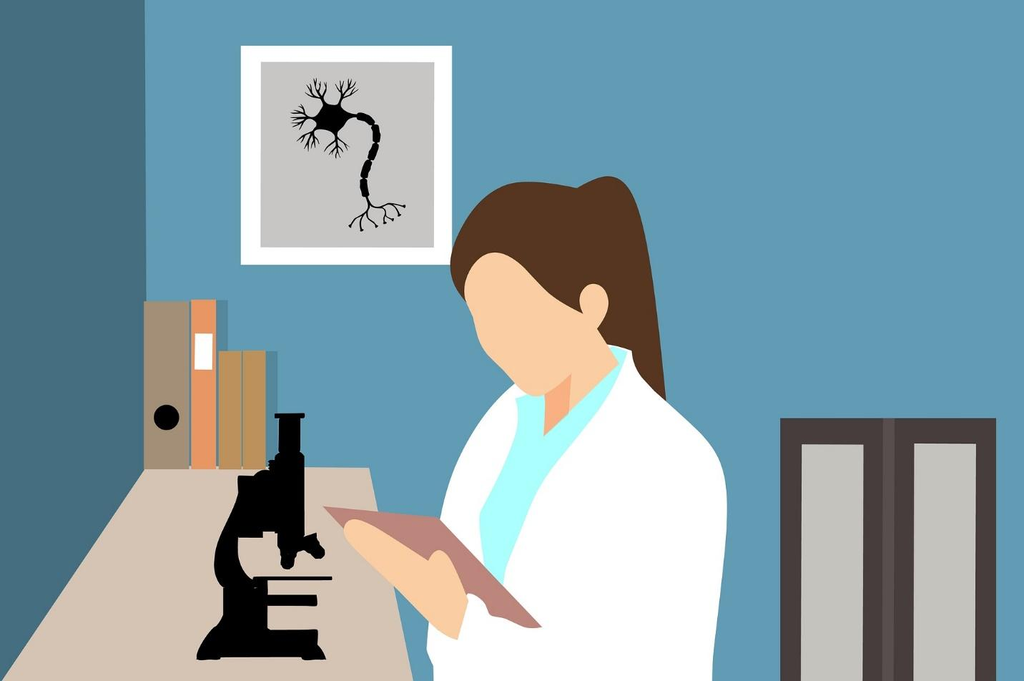

## “Proof” in science

**Science does not prove ideas**

**Instead, it works by rejecting hypotheses based on supporting and refuting evidence to advance understanding**

**Findings are tentative since the REAL explanation may not have been considered**

**Science is based on the principle that any idea, no matter how widely accepted, can be overturned if evidence warrants it**

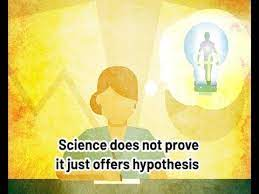

## Science is ongoing

- **The scientific process produces results that can be used in both inductive and deductive reasoning:**
  - Allow generalization (inductive reasoning)
  - Supports or rejects a model or theory (deductive)
- **Research always generates more questions than answers!**

[figure not shown]

## Practical development of research questions

- **The research you perform depends on many factors:**
  - Your interest
  - Your goal
  - Area of biological research
  - Research setting
  - Resources available

[figure not shown]

## Different kinds of research have different goals

- **Scientific research can be roughly divided into two categories with different goals**
  - *Basic research* – research about how the world works
    - Driven by curiosity
    - No obvious or immediate commercial value
  - *Applied research* – research with specific aims
    - To solve practical problems: technological / medical
    - Relies upon previous basic research

**Both are extremely important to drive scientific and technological advancement**

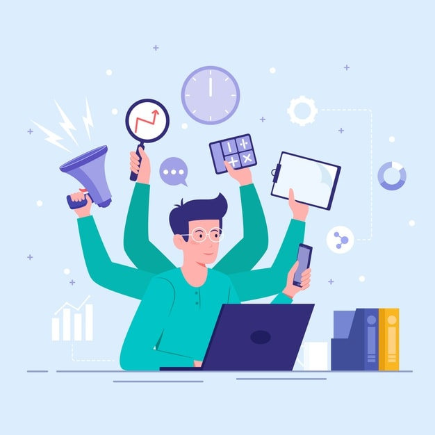

## Examples of different research types in human health…

**Examples of basic research:**

1. An investigation into the symptoms of diarrhea.
2. An investigation into the secondary symptoms of the Human Papilloma Virus (HPV)

**Examples of applied research:**

1. An investigation to determine the healing properties of mushrooms.
2. An investigation to determine the side effects of alcohol consumption.

## Science, technology, and society are interrelated

**Science and technology rely on each other to provide benefits for society**

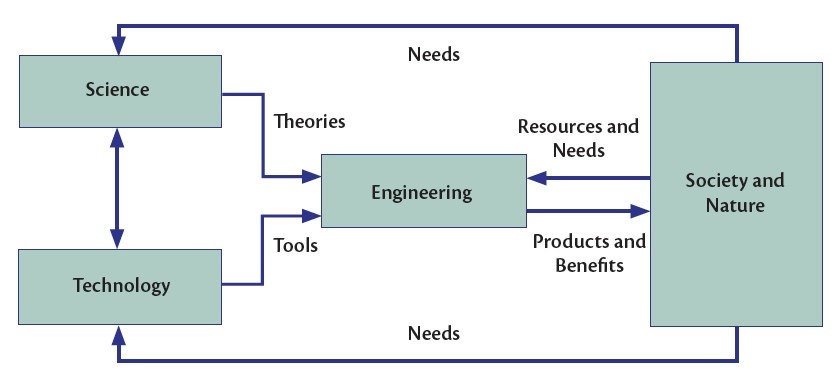

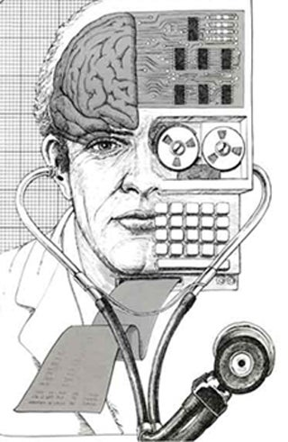

## Research Settings (potential careers)

**The place research is being conducted determines the kinds of questions that will be investigated**

- **Each setting has advantages and disadvantages**
  - *Academic – small institution* (Shepherd University)
    - Great freedom, undergrad students
    - low budget, lack of equipment
  - *Academic – large research institution* (WVU)
    - Great freedom, advanced equipment, graduate students
    - constant scramble for grant money
  - *Industrial* – biotech, pharmaceutical, agriculture (Pfizer)
    - Advanced equipment, staff focused on a single task
    - Less freedom
  - *Government* (Department of Defense, USDA, NIH)
    - Some degree of freedom
    - Red tape, scramble for money

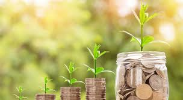

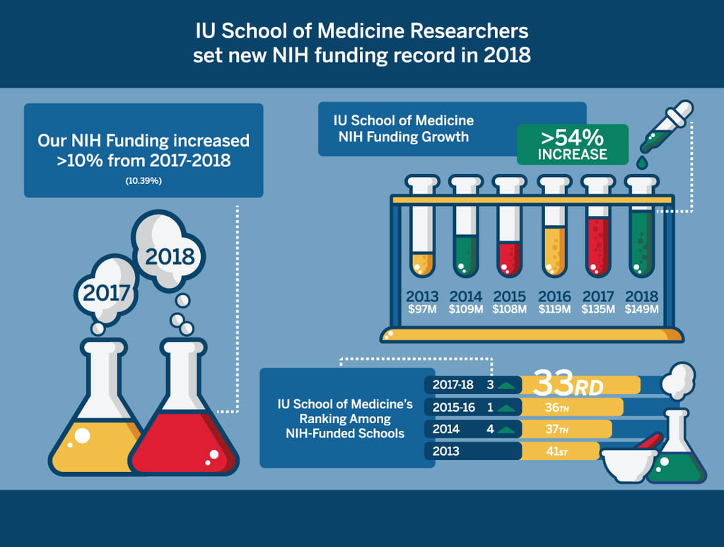